# Fuentes de datos: Padrón Único Nacional de Alojamiento (PUNA)

Siguiendo con la política de apertura de datos, la Dirección Nacional de Mercados y Estadística pone a disposición principales indicadores y la base de datos agregada de alojamientos colectivos 2020 del PUNA.

## ¿QUÉ ES EL PADRÓN ÚNICO NACIONAL DE ALOJAMIENTO?

El Padrón Único Nacional de Alojamiento (PUNA) es el resultado de un proceso de armonización y consolidación de la información aportada por los organismos provinciales y municipales de turismo a través de sus registros administrativos y por el INDEC a partir del registro del marco poblacional de la Encuesta de Ocupación hotelera y Parahotelera (EOH).

Los diferentes organismos de turismo de cada provincia o municipio cuentan con la información del número de establecimientos hoteleros, parahoteleros y otros alojamientos colectivos de turismo, resultante del proceso de habilitación que realizan las correspondientes dependencias para la prestación del servicios de alojamiento. A su vez, a partir de la información que recoge la EOH en las localidades muestradas, para la construcción del marco muestral de interés, se incorporan dichos registros al padrón de alojamiento.

Como resultado el PUNA reúne la información de los establecimientos de alojamiento turístico colectivo de la Argentina, detallando las principales variables de cada uno.

## ¿QUÉ ES UN ALOJAMIENTO TURÍSTICO COLECTIVO?

Los alojamientos turísticos colectivos son aquellos establecimientos de hospedaje que prestan servicios de alojamiento al viajero, ofreciendo habitaciones u otro acomodo, si bien el número de plazas debe ser superior a un mínimo determinado, para grupos de personas que sobrepasan la unidad familiar y debe disponer, aunque no tenga fines de lucro, de una administración de tipo comercial común para todas las plazas del establecimiento. Esta definición incluye a los establecimientos hoteleros, parahoteleros, especializados y otros establecimientos colectivos (como los alojamientos de vacaciones; alojamientos de camping turístico; puertos; establecimientos de alojamiento turístico social).

## ¿QUÉ PERMITE ANALIZAR EL PUNA?

Los datos del PUNA permiten conocer para 1265 localidades del país el stock de establecimientos, plazas y habitaciones disponibles según el tipo y categoría del establecimiento, número de establecimientos y plazas de cadenas hoteleras y origen de la cadena.

Por ejemplo, a partir de la base de alojamientos turísticos colectivos agrupada podemos analizar cómo se distribuyó el stock de plazas de alojamiento colectivo a lo largo del país durante el 2020 por provincia.

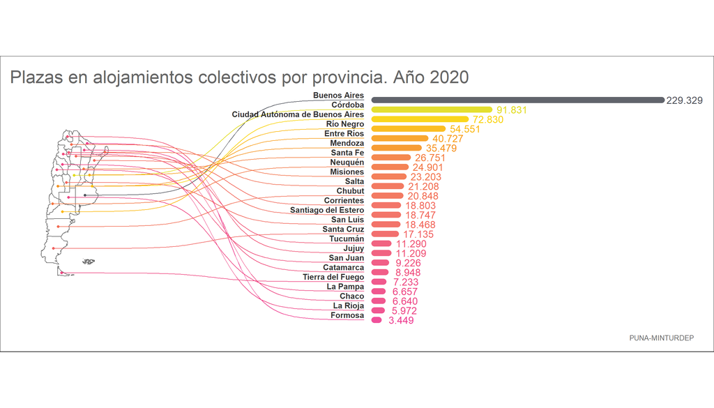

```r
data_gg2 <- puna %>%
#  filter(tipo == "Hoteleros") %>%
  group_by(provincia) %>%
  summarise(plazas = sum(as.numeric(plazas))) %>%
  ungroup() %>%
 # mutate(orden = rank(-plazas)) %>%
  arrange(-plazas) %>%
  mutate(prov_limpio = limpiar_texto(provincia)) %>%
  filter(!is.na(plazas))


mapa_arg <- get_geo("ARGENTINA", level = "provincia") %>%
  add_geo_codes() %>%
  mutate(prov_limpio = limpiar_texto(name_iso))

data_gg2 <- right_join(mapa_arg, data_gg2)


data_gg2 <- data_gg2 %>%
  st_centroid(of_largest_polygon = T)

data_gg2 <- data_gg2 %>%
  bind_cols(
    sf::st_coordinates(data_gg2) %>%
      as_tibble() %>%
      rename(lon=X, lat=Y))

# corregir centroide de salta
data_gg2 <- data_gg2 %>%
  mutate(lon = ifelse(name_iso == "Salta", -64.59388437680094, lon),
         lat = ifelse(name_iso == "Salta", -25.110770602277693, lat))

data_gg2 <- datos_grafico_pablo(data_gg2, variable = plazas)


ggplot(data_gg2) + #data
  geom_sf(data=mapa_arg, size = .5, fill = "transparent", color = "gray40") + # mapa base
  geom_point(aes(x=lon, y=lat, color=plazas)) + #data: puntos
  geom_sigmoid(
    aes(x=lon, y=lat, xend=sigmoid_end, yend=col_y, group=name_iso, color=plazas)
  ) + #data: lineas
  geom_text(
    aes(label=name_iso, x=sigmoid_end, y=col_y
        #color=plazas
        ), color = "black", fontface = "bold",
    hjust=1, size=4, vjust=0, nudge_y = 0.5, alpha=0.8,
  ) + #data: etiquetas
  geom_segment(
    aes(x = col_x_start, xend = col_x_end, y = col_y, yend = col_y, color = plazas),
    size = 4.2, alpha = .9,
    lineend = "round"
  ) + #data: barras
  geom_text(
    aes(label=area_label, x=col_x_end, y=col_y, color=plazas),
    hjust=-0.1, size=5, nudge_x = .3
  ) + #data: valores
  labs(
    subtitle = "Plazas en alojamientos colectivos por provincia. Año 2020",
    caption = "PUNA-MINTURDEP"
  ) +
  coord_sf(clip = "off") +
  scale_fill_dnmye2(discrete = F) +
  scale_color_dnmye2(discrete = F) +
  theme_void() +
  theme(plot.margin = margin(.5, 1, .5, .5, "cm"),
        legend.position = "none",
        plot.background = element_rect(fill = "transparent"),
        plot.caption = element_text(color = "gray40", size = 10),
        plot.title = element_text(color = "gray40", size = 25, family = "Helvetica", face = "bold"),
        plot.subtitle = element_text(color = "gray40", size = 25))
```

También podemos hacer el análisis a nivel de localidad y consultar cuáles fueron las quince localidades del país con mayor stock de plazas totales.

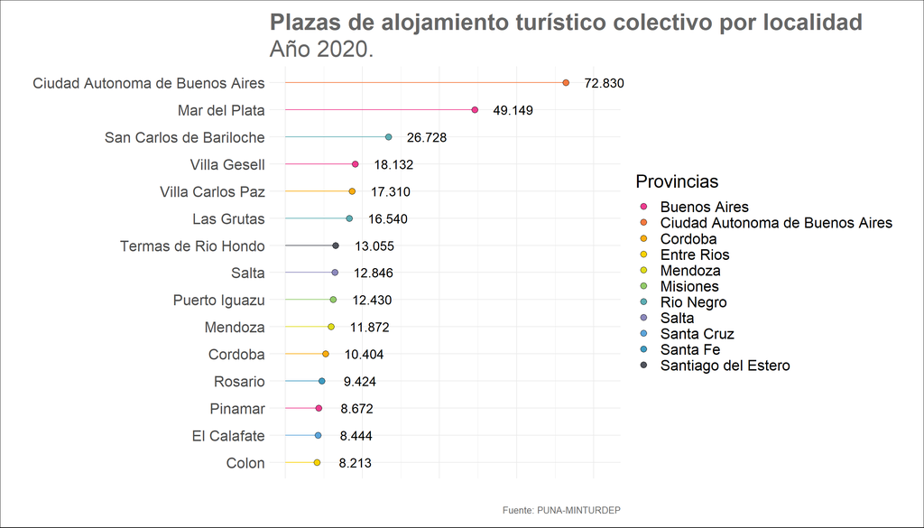

```r
data_gg <- puna %>%
  filter(!is.na(plazas) & plazas != 0) %>%
  group_by(provincia, localidad) %>%
  summarise(plazas = sum(as.numeric(plazas))) %>%
  ungroup() %>%
  arrange(plazas) %>%
  mutate(localidad = as_factor(localidad),
         orden = as.integer(rank(-plazas)))

data_gg %>%
  slice_tail(n = 15) %>%
  ggplot() +
    geom_segment(aes(x = localidad, xend = localidad,
                     y = 0, yend = plazas,
                     color =provincia)) +
  geom_point(aes(x = localidad, y = plazas, fill = provincia), color = "black",
             size = 3, shape = 21) +
  geom_text(aes(x = localidad, y = plazas+10000,
                label = scales::label_number(big.mark = ".", decimal.mark = ",", accuracy = 1)(plazas)
), color = "black",
             size = 5) +
  coord_flip(clip = "off") +
  theme_minimal()  +
  scale_fill_dnmye2() +
  scale_color_dnmye2() +
  xlab("") +
  ylab("") +
  scale_y_continuous(labels = NULL) +
  guides(fill = guide_legend(title = "Provincias"), color = "none") +
  theme(plot.margin = margin(.5, 1, .5, .5, "cm"),
        text = element_text(size = 20),
        legend.position = "right",
        plot.background = element_rect(fill = "transparent"),
        plot.caption = element_text(color = "gray40", size = 10),
        plot.title = element_text(color = "gray40", size = 25, family = "Helvetica", face = "bold", hjust = 0),
        plot.subtitle = element_text(color = "gray40", size = 25)) +
  labs(title = "Plazas de alojamiento turístico colectivo por localidad", subtitle = "Año 2020.", caption = "Fuente: PUNA-MINTURDEP")
```

Además de analizar el stock de plazas es posible indagar en función de otras variables como el tipo de establecimiento o su clasificación. En el PUNA los establecimientos colectivos se clasifican en tres tipos: hoteleros, parahoteleros, y otros colectivos. Cada tipo a su vez tiene su propia clasificación, los alojamientos hoteleros se clasifican en diez categorías diferentes.

Una posible lectura que aporta esto es conocer qué porcentaje de las plazas hoteleras de cada provincia conforman los hoteles sindicales o mutuales. En el siguiente gráfico se representa el total de plazas hoteleras, la suma de plazas hoteleras de clasificación mutual o sindical y qué porcentaje estas últimas representan sobre el total hotelero.

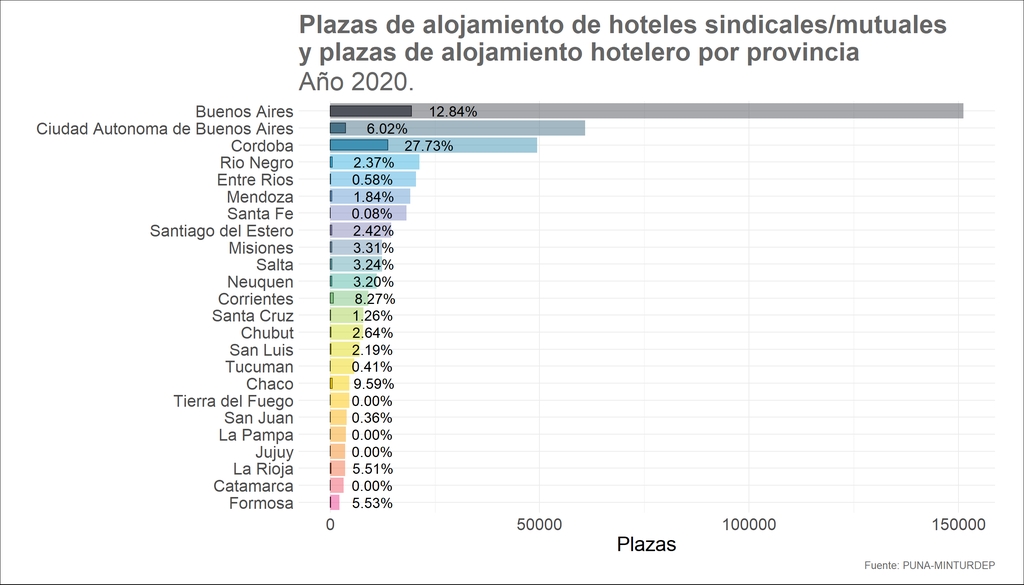

```r
data_gg3 <- puna %>%
  filter(tipo == "Hoteleros") %>%
  complete(provincia, clasificacion_minturdep) %>%
  group_by(provincia, clasificacion_minturdep) %>%
  summarise(plazas = sum(as.numeric(plazas), na.rm = T)) %>%
  ungroup() %>%
  group_by(provincia) %>%
  mutate(porcentaje = plazas /sum(plazas, na.rm = T),
         total = sum(plazas)) %>%
  filter(clasificacion_minturdep == "Hotel sindical / mutual") %>%
  ungroup() %>%
  arrange(total) %>%
  mutate(provincia = as_factor(provincia))


ggplot(data = data_gg3) +
  geom_col(aes(x = provincia,
               y = plazas,
               fill = provincia), width = .6, color = "black" ) +
  geom_col(aes(x = provincia,
               y = total,
               fill = provincia), alpha = .5 ) +
  geom_text(aes(x = provincia,
               y = plazas+10000,
               label  = scales::label_percent(accuracy = 0.01)(porcentaje)),
             size = 5) +
  guides(fill = "none") +
  coord_flip() +
    theme_minimal()  +
  scale_fill_dnmye2() +
  scale_color_dnmye2() +
  xlab("") +
  ylab("Plazas") +
 # guides(fill = guide_legend(title = "Provincias"), color = "none") +
  theme(plot.margin = margin(.5, 1, .5, .5, "cm"),
        text = element_text(size = 20),
        legend.position = "none",
        plot.background = element_rect(fill = "transparent"),
        plot.caption = element_text(color = "gray40", size = 10),
        plot.title = element_text(color = "gray40", size = 25, family = "Helvetica", face = "bold", hjust = 0),
        plot.subtitle = element_text(color = "gray40", size = 25)) +
  labs(title = "Plazas de alojamiento de hoteles sindicales/mutuales\ny plazas de alojamiento hotelero por provincia", subtitle = "Año 2020.", caption = "Fuente: PUNA-MINTURDEP")
```

## RECURSOS DISPONIBLES PARA CONSULTA

### Tablero Interactivo

Desde **[acá](https://tableros.yvera.tur.ar/puna/)** se puede acceder a la información del PUNA en formato de tabla dinámica interactiva para que puedas cruzar los datos por diferentes variables de interés.

### Datos Abiertos

Además se encuentra disponible para su consulta y descarga en el [portal de datos abiertos](https://datos.yvera.gob.ar/dataset/padron-unico-nacional-alojamiento) del Sistema de Información Turística de la Argentina ([SINTA](https://www.yvera.tur.ar/sinta/)) los siguientes recursos:

- [Cantidad de plazas, habitaciones y establecimientos de alojamiento turístico colectivo por provincia](https://datos.yvera.gob.ar/dataset/padron-unico-nacional-alojamiento/archivo/67727a58-7a43-450d-a685-a9fba9218b20).
- [Cantidad de plazas, habitaciones y establecimientos de alojamiento turístico colectivo por provincia según categoría](https://datos.yvera.gob.ar/dataset/padron-unico-nacional-alojamiento/archivo/d948548d-bc56-4462-b5cd-cc425fedf0e7).
- [Cantidad de plazas y establecimientos de cadenas hoteleras según tipo de cadena hotelera](https://datos.yvera.gob.ar/dataset/padron-unico-nacional-alojamiento/archivo/f7f748b8-5852-4ca5-bc05-fe7dedafa254).
- [Base de alojamientos turísticos colectivos agrupada por provincia, departamento y localidad según clasificación y tipo de alojamiento del Padrón Único Nacional de Alojamiento (PUNA) con detalle de cantidad de establecimientos, unidades, habitaciones y plazas](https://datos.yvera.gob.ar/dataset/padron-unico-nacional-alojamiento/archivo/01d23e57-ba58-48ed-a1c9-e1604ae78a1d).
- [Ficha técnico metodológica del PUNA](https://datos.yvera.gob.ar/dataset/padron-unico-nacional-alojamiento/archivo/3aef82ad-ab6a-455a-a9dc-2bcb39755959)